# STA207 project – Analysis on Factors Affecting the Confirmed Cases Amount of COVID-19

Bo Zhang

2/18/2022

## Abstract

Coronavirus disease 2019 (COVID-19) is a contagious desease caused by SARS-CoV-2. The main symptoms for COVID-19 are fever, cough, difficulty breathing, fatigue and diarrhea with an incubation period between 1 to 14 days. According to World Health Organization, there have been 452,201,564 confirmed cases including 6,029,852 deaths of COVID-19 since this pandemic started as of March 13 2022. Since around 1/3 of infected person are asymptomatic carrier, it would be really difficult for government and people to be prepared and free from infection. Therefore, researchers are dedicated to find significant factors to the amount of confirmed cases for each country.

This project would use a two-way ANOVA model to mainly investigate the influence of two factors: human development degree and population density affecting the number of confirmed cases among the whole world. A comprehensive data preprocessing is done to tidy the data set, including handling missing values and split groups of each factor. Exploratory data analysis is conducted to better understand the data, such as the distributions and level differences. After that, the ANOVA model has been constructed, investigated and evaluated.

As a result, the significant factor level has been tested and selected. Also, further discussions are made for the models, dataset, and the entire analysis process at the end of this project.

## Introduction

### Background

Based on current research, there is enough evidence showing that the social distance will affect the rate of infection since the main affection way of COVID-19 virus is via airborne particles and droplets. Therefore, it’s straight forward to think about the influence of population density level on the confirmed cases amount. Besides, we would consider that maybe for developed country, there will be better ways to prevent and treat the virus, but for underdeveloped country, maybe there isn’t enough resources to prevent the spread of the virus. Therefore, it lead to another curiosity of is there significant difference for the influence of different development level on the amount of confirmed cases.

## Dataset Wrangling

### Dataset Introduction

There are 2 main datasets and 2 extra datasets being used in this project:

**WHO cumulative covid cases dataset**  
The first data set is retrieved from World Health Organization (https://covid19.who.int/WHO-COVID-19-global-table-data.csv), which contains the daily cases and deaths by date reported to WHO from 01/03/2020, the beginning of the pandemic, to 03/01/2022. There are 189420 rows and 8 columns in total, the part will be included in the project is:

| Column_Name | Description |
| --- | --- |
| **Date_reported** | Date of reporting to WHO |
| **Country_code** | ISO Alpha-2 country code |
| **Country** | Country/territory/area |
| **Cumulative_cases** | Cumulative confirmed cases reported to date |

**Our World In Data economic and population dataset**  
The second data set is retrieved from Our World In Data (https://ourworldindata.org/coronavirus), which contains the daily cases from 01/03/2020 to 03/01/2022, basic information of each country, such as gdp, population, amount of hospital, etc. There are 165408 rows and 67 columns inside the dataset. The part will be included in later analysis is:

| Column_Name | Description |
| --- | --- |
| **date** | Date of reporting |
| **iso_code** | ISO Alpha-3 country code |
| **location** | Country/territory/area |
| **total_cases** | Cumulative confirmed cases reported to date |
| **total_cases_per_million** | Cumulative confirmed cases per 1 million people |
| **population** | population for each area |
| **population_density** | the number of people per square kilometer |
| **gdp_per_capita** | a country’s GDP divided by the population |
| **human_development_index** | a summary measure of the level of a country’s social and economic development |

**International Organization for Standardization country code dataset**  
The third data set has been used is retrieved from the International Organization for Standardization (https://www.iso.org/obp/ui/#search), which include the country name and country ISO code. It contains 249 rows and 3 columns.

| Column_Name | Description |
| --- | --- |
| **English_short_name** | Country/territory/area |
| **Alpha-2 code** | ISO Alpha-2 country code |
| **Alpha-3 code** | ISO Alpha-3 country code |

**Our World In Data human development index dataset**  
The fourth data set is retrieved from Our World In Data (https://ourworldindata.org/human-development-index), which include a complete list of human development index updated to the year of 2022 for each country/area. It contains 229 rows and 3 columns.

| Column_Name | Description |
| --- | --- |
| **Country** | Country/territory/area |
| **Continent** | which continent should this country belongs to |
| **HDI** | human development index, a summary measure of the level of a country’s social and economic development |

### Data Preprocessing

#### feature selection

Based on our question of interest, to analyze the impact of country development level and population density level on the confirmed cases among the whole world. Since the cumulative cases has been keep adding the new confirmed cases every day, the data has been reorganized as choosing only the cumulative confirmed cases from the most recent date for each country, which is March 01, 2022. We could clearly see that there exists several 6-digit code under the ISO Alpha country code in the second dataset, which are self-defined categories such as income level, the dataset has been used for further analysis keeps only legally authorized country/territory/area.

In order to join the two dataset for developing future analysis, the most consistent variable could be used would be the ISO Alpha-2 country code and ISO Alpha-3 country code. The third dataset has been used to match these two type of code correspondingly.

|  | Country | date | total_cases_per_million | population_density | human_development_index |
| --- | --- | --- | --- | --- | --- |
| 1 | Aruba | 2022-03-01 | 314231.074 | 584.8 |  |
| 2 | Afghanistan | 2022-03-01 | 4364.934 | 54.422 | 0.511 |
| 3 | Angola | 2022-03-01 | 2909.976 | 23.89 | 0.581 |
| 4 | Anguilla | 2022-03-01 | 168925.62 |  |  |
| 5 | Albania | 2022-03-01 | 94573.004 | 104.871 | 0.795 |
| 6 | Andorra | 2022-03-01 | 493381.079 | 163.755 | 0.868 |
| 7 | United Arab Emirates | 2022-03-01 | 88123.68 | 112.442 | 0.89 |
| 8 | Argentina | 2022-03-01 | 195242.086 | 16.177 | 0.845 |
| 9 | Armenia | 2022-03-01 | 141555.89 | 102.931 | 0.776 |
| 10 | Antigua and Barbuda | 2022-03-01 | 75429.463 | 231.845 | 0.778 |

[output cut: 210 more lines]

#### Missing Values

After combined these two dataset together, according to the missing value table below, there are 15 missing values for population density, and 31 missing values for human development index. It’s around 15% of the total data which is not reasonable to remove all missing values. Therefore, the fourth dataset has been used to fill in the missing population density and human_development_index. There still exists 6 country/area doesn’t provide any valid data that could be used to fill in manually. In this case, I decided to remove them.

Countries which have 0 cumulative cases and 0 cumulative cases per million, are mainly island country where mostly rely on marine transportation, have only few air route or even no air route. These countries are restricting travel and even instituting a national lock down in the early stages of the pandemic, which makes them successfully prevented from COVID-19 virus. Therefore I decided to not research those 0 confirmed cases since they could be seen as completely independent area with all other countries among the world. The main focus is on the influence of HDI and density level on confirmed cases, for those don’t have cases at all, we can ignore them at this stage.

|  | Country | Date_reproted | total_cases_per_million | population_density | human_development_index |
| --- | --- | --- | --- | --- | --- |
| **Raw Data** | 0 | 0 | 9 | 15 | 31 |
| **Combined Data** | 0 | 0 | 9 | 4 | 6 |
| **NA Omitted Data** | 0 | 0 | 0 | 0 | 0 |

#### Categorical Variable Processing

In order to discover the answer for our question of interest, I need to further tidy up the dataset.

[output not shown]

#### Data Transformation

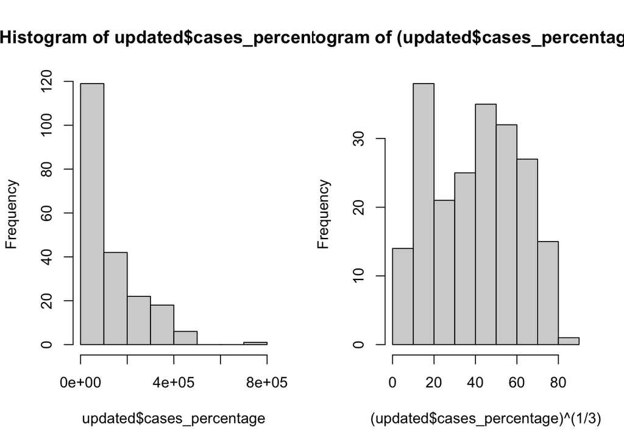

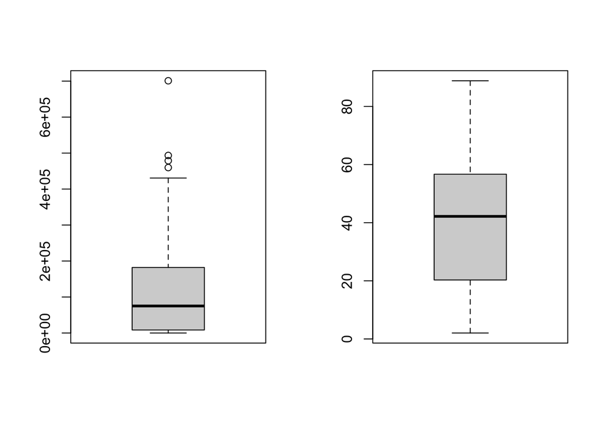

Besides, two factors will be used in further study has been set as factor variables.

Our final dataset is shown below:

|  | Country | cases_trans | HDI | density_level |
| --- | --- | --- | --- | --- |
| 1 | Afghanistan | 16.3427784696943 | low | dense |
| 2 | Albania | 45.5605608257662 | high | very dense |
| 3 | Algeria | 18.1101415444703 | high | moderate |
| 4 | Andorra | 79.0182662990458 | veryhigh | very dense |
| 5 | Angola | 14.2767647183474 | medium | moderate |
| 6 | Anguilla | 55.2796358958539 | veryhigh | very dense |
| 7 | Antigua and Barbuda | 42.2519741383508 | high | very dense |
| 8 | Argentina | 58.0128871482545 | veryhigh | moderate |
| 9 | Armenia | 52.11658874719 | high | very dense |
| 10 | Aruba | 67.9855126288004 | veryhigh | very dense |

[output cut: 198 more lines]

## Data Exploratory

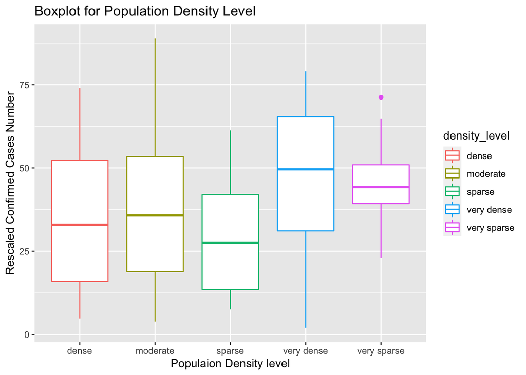

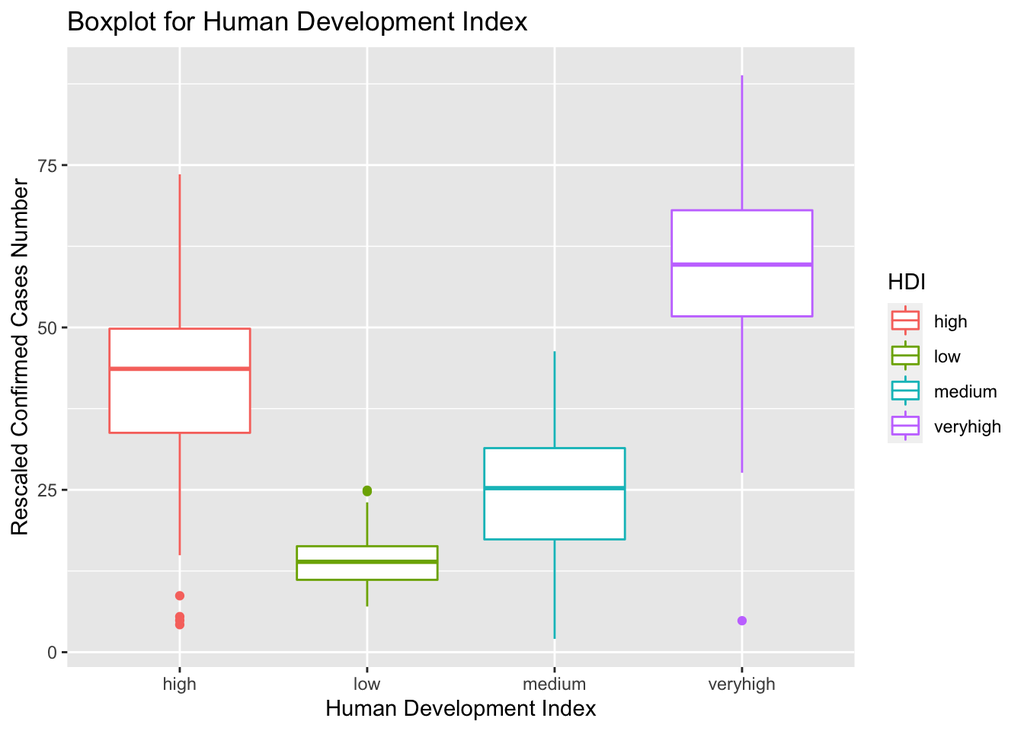

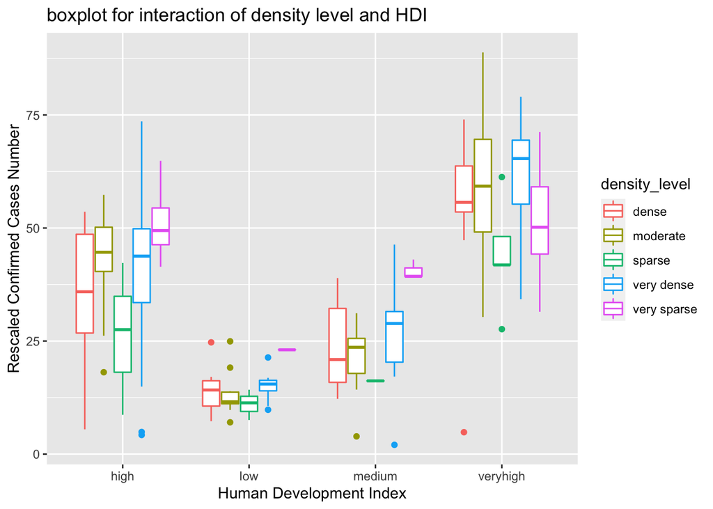

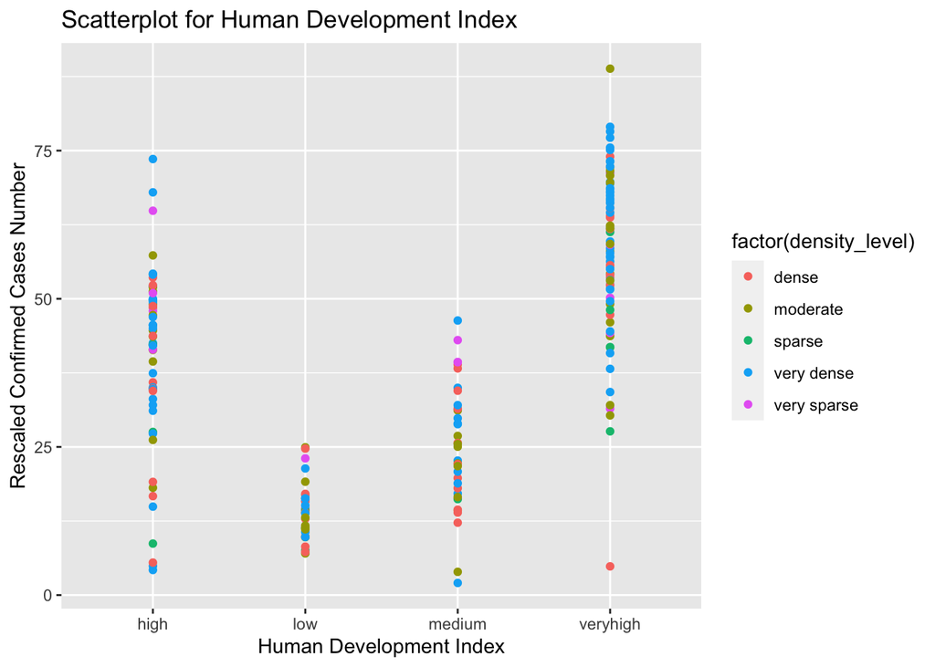

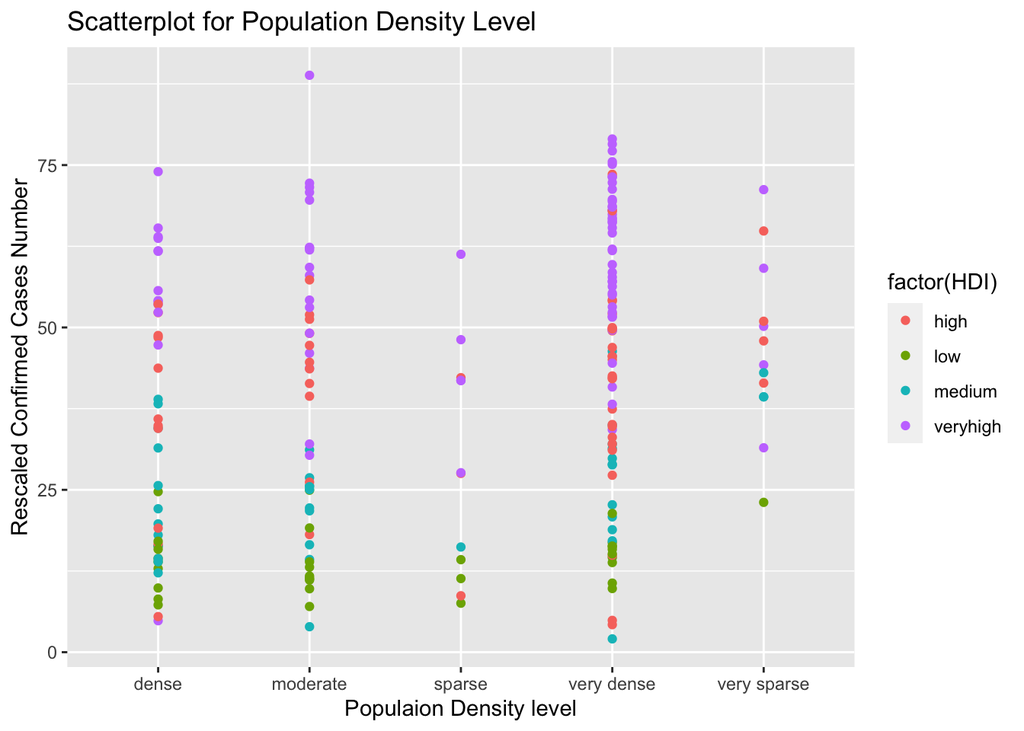

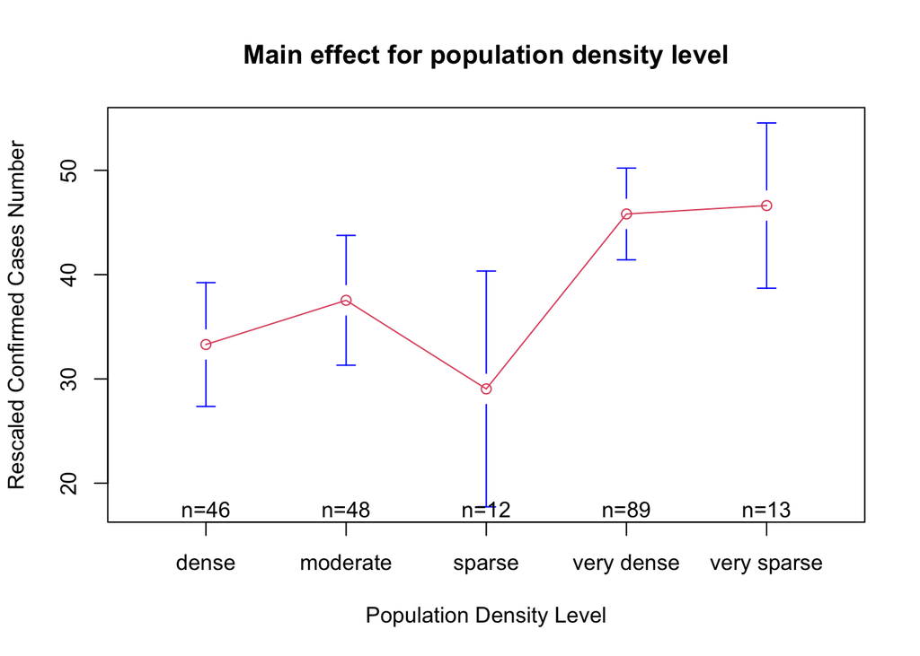

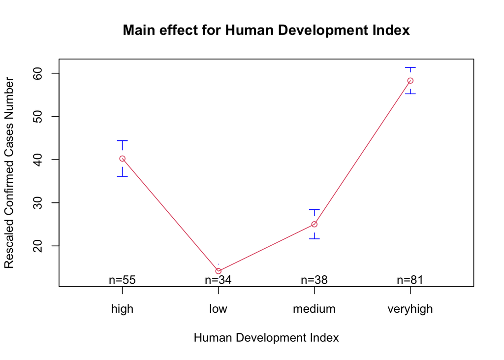

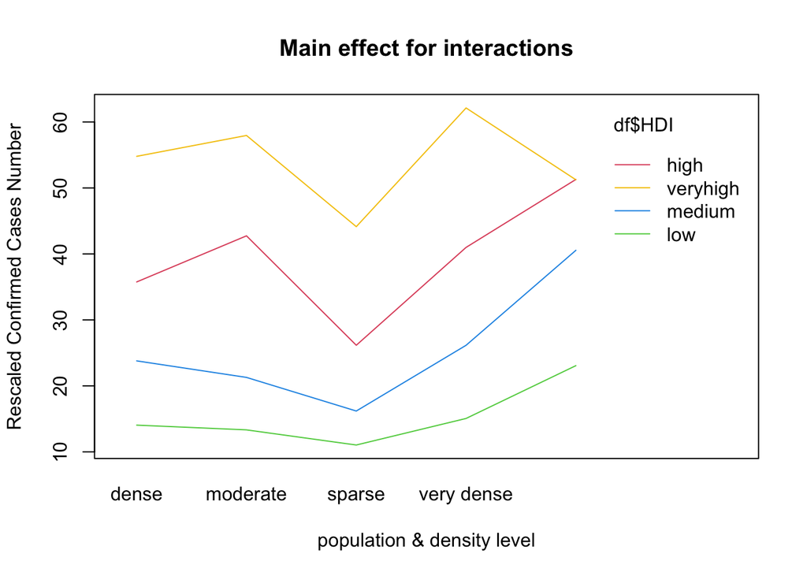

Thus a two-way ANOVA model will be used to investigate the influence of each factor on the response variable.

## Model Construction

Two two-way ANOVA models would be constructed for future analysis.

**Full Model:**

We would define the two-way ANOVA **full model** as:
$$Y_{ijk} = \mu_{..} + \alpha_i + \beta_j +
\alpha\beta_{ij} + \epsilon_{ijk}$$

- **Index:**
  - index i represents the HDI level: low (i=1), medium (i=2), high (i=3), and very high (i=4)
  - index j represents the population density level: very sparse (i=1), sparse (i=2), moderate (i=3), dense (i=4), very dense (i=5)
  - index k represents the country/territory/area.
- **Parameter:**
  - $\mu_{..}$ is the mean cumulative cases number among all countries.
  - $\alpha_i$ represents the average cumulative cases number for each HDI level, which is the mean factor effect on HDI level;
    $$\alpha_i =
    \mu_{i.}-\mu_{..}$$
  - $\beta_j$, represents the average cumulative cases number for each population density level, which is the mean factor effect on population density level;
    $$\beta_j = \mu_{.j}-\mu_{..}$$
  - $\alpha\beta_{ij}$ represents the average cumulative cases number for the interaction term of each pair of population density level and HDI level, which is the mean factor effect on interaction of HDI and population density level.
    $$\alpha\beta_{ij} =
    \mu_{ij}-\mu_{i.}-\mu_{.j}-\mu_{..}$$
  - $\epsilon_{ijk}$ represents the error term for each country, which should follows the normal distribution.
  - $Y_{ijk}$ is the cumulative cases number for each country, having HDI level i and population density level j.
- **Constrains:**

  $$\sum\alpha_i = \sum\beta_j=0$$
  $$\sum_{i=1}^a(\alpha\beta_{ij}) =
  \sum_{j=1}^b(\alpha\beta_{ij}) = 0$$
- **Assumptions:**
  - the residuals are independent, and identically distributed, have equal variance
  - the variables are categorized
  - there isn’t any significant outlier

**Reduced Model:**

We would define the two-way ANOVA **reduced model** as
$$Y_{ijk} = \mu_{..} + \alpha_i + \beta_j +
\epsilon_{ijk}$$

- **Index:**
  - index i represents the HDI level: low (i=1), medium (i=2), high (i=3), and very high (i=4)
  - index j represents the population density level: very sparse (i=1), sparse (i=2), moderate (i=3), dense (i=4), very dense (i=5)
  - index k represents the country/territory/area.
- **Parameter:**
  - $\mu_{..}$ is the mean cumulative cases number among all countries.
  - $\alpha_i$ represents the average cumulative cases number for each HDI level, which is the mean factor effect on HDI level;
    $$\alpha_i =
    \mu_{i.}-\mu_{..}$$
  - $\beta_j$, represents the average cumulative cases number for each population density level, which is the mean factor effect on population density level;
    $$\beta_j = \mu_{.j}-\mu_{..}$$
  - $\epsilon_{ijk}$ represents the error term for each country, which should follows the normal distribution.
  - $Y_{ijk}$ is the cumulative cases number for each country, having HDI level i and population density level j.
- **Constrains:**

  $$\sum\alpha_i=\sum\beta_j=0$$
- **Assumptions:**
  - the residuals are independent, and identically distributed, have equal variance
  - the variables are categorized
  - there isn’t any significant outlier

Analysis of Variance Table

| Res.Df | RSS | Df | Sum of Sq | F | Pr(>F) |
| --- | --- | --- | --- | --- | --- |
| 200 | 29959 | NA | NA | NA | NA |
| 188 | 27981 | 12 | 1978 | 1.107 | 0.3564 |

Based on the ANOVA table of full model and reduced model above, $Pr(>F) = 0.3564$ for full model, which means that there isn’t enough evidence to reject the reduced model. Therefore, reduced model will be used and interaction term will be dropped for future investigation.

**Hypothesis Test on Reduced Model:**

Analysis of Variance Model

|  | Df | Sum Sq | Mean Sq | F value | Pr(>F) |
| --- | --- | --- | --- | --- | --- |
| **HDI** | 3 | 58382 | 19461 | 129.9 | 1.003e-46 |
| **density_level** | 4 | 2523 | 630.9 | 4.212 | 0.002696 |
| **Residuals** | 200 | 29959 | 149.8 | NA | NA |

|  | Estimate | Std. Error | t value | Pr(>\|t\|) |
| --- | --- | --- | --- | --- |
| **(Intercept)** | 37.48 | 2.34 | 16.01 | 1.088e-37 |
| **density_levelmoderate** | 1.941 | 2.53 | 0.7675 | 0.4437 |
| **density_levelsparse** | -8.509 | 3.988 | -2.134 | 0.0341 |
| **density_levelvery dense** | 4.827 | 2.264 | 2.132 | 0.03419 |
| **density_levelvery sparse** | 7.554 | 3.861 | 1.957 | 0.05178 |
| **HDIlow** | -24.8 | 2.698 | -9.192 | 5.077e-17 |
| **HDImedium** | -14.88 | 2.603 | -5.717 | 3.899e-08 |
| **HDIveryhigh** | 18.02 | 2.141 | 8.419 | 7.283e-15 |

Fitting linear model: cases_trans ~ density_level + HDI

| Observations | Residual Std. Error | $R^2$ | Adjusted $R^2$ |
| --- | --- | --- | --- |
| 208 | 12.24 | 0.6703 | 0.6588 |

Therefore, based on $\alpha = 0.05$, we are 95% confidence that every level of both factors, except density level ‘moderate’ and ‘very sparse’, is significant to the amount of confirmed cases.

We will explore whether there exists a combination such that it has the most significant influence on the cases amount, and if possible, which combination of factor is.

**Significant difference within groups**

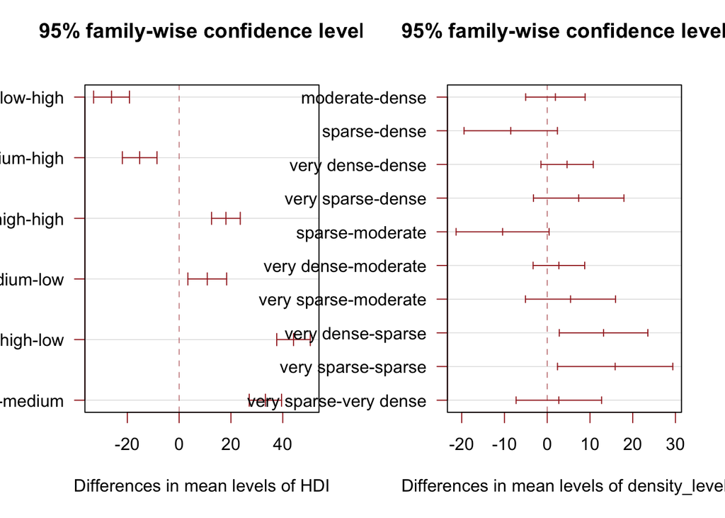

From the plot of pairwise confidence interval, we could conclude that we are 95% sure that all HDI level exist significant difference on confirmed cases amount, the group `'very high' & 'low'` exists largest difference on total confirmed cases; Besides, we are 95% confidence that for density level, the pair `'very dense' & 'sparse'` exists significant difference on confirmed cases amount; .

**Most Significant Pair of Group**

The table below shows the difference of the mean within each group, the cell having largest means is `(very high, very dense)`, which means that if a country is having very dense population density and very high human development Index, then it has the largest probability of having the most confirmed cases amount of COVID-19.

|  | dense | moderate | sparse | very dense | very sparse |
| --- | --- | --- | --- | --- | --- |
| **high** | 35.76 | 42.75 | 26.16 | 40.99 | 51.29 |
| **low** | 14.06 | 13.34 | 11.04 | 15.07 | 23.07 |
| **medium** | 23.8 | 21.29 | 16.19 | 26.16 | 40.55 |
| **veryhigh** | 54.79 | 57.96 | 44.14 | 62.13 | 51.24 |

## Sensitivity Analysis

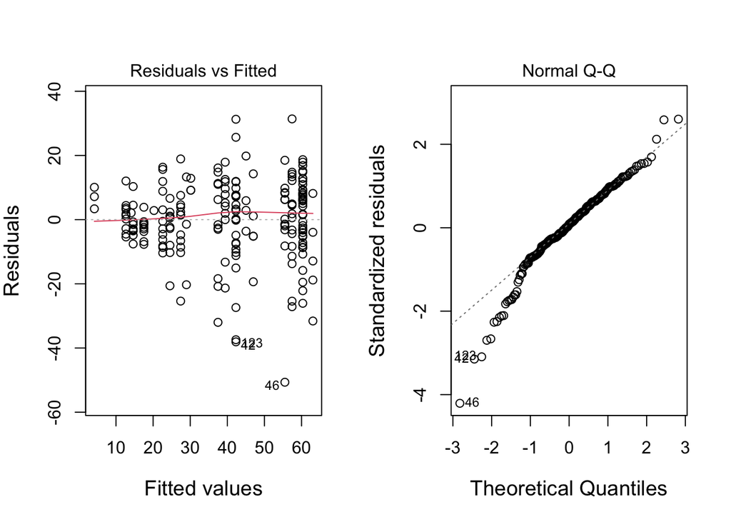

According to the residual plot of the fitted model, we could see that the residuals don’t have clear pattern, and from the qq-plot, they scattered evenly in the middle part of this distribution. However, the left end of the shape is not scattered around the line evenly, which is kind of not normal. Thus we could apply a Shapiro-Wirk test and a Levene’s test on our dataset to check the normality and the equality of variance.

**Testing for normality:**

Shapiro-Wilk normality test: `anova.fit$residuals`

| Test statistic | P value |
| --- | --- |
| 0.9564 | 5.544e-06 * * * |

**Shapiro-Wirk test**  
Null Hypothesis: the residuals are normally distributed.  
Alternative Hypothesis: the residuals are not normally distributed.

**Testing for equal variance:**

Levene’s Test for Homogeneity of Variance (center = median)

|  | Df | F value | Pr(>F) |
| --- | --- | --- | --- |
| **group** | 19 | 1.558 | 0.07064 |
|  | 188 | NA | NA |

**Levene’s test**  
Null Hypothesis: the population variances for each group are equal.  
Alternative Hypothesis: at least two of the population variance are different from other groups.

since $Pr(>F) = 0.07$, at the significant level $\alpha = 0.05$, we could not reject the null hypothesis. Thus we conclude that there isn’t enough evidence showing that at least two of the variances from these groups are different.

## Causal Inference

Based on the question of interest, to analyze is there an independent, actual effect for the factors Human Development Index and Population Density among the whole system, it would be needed to bring in a causal inference to determine the illustrate if it is a causation or a correlation.

To test the causation of Human Development Index, we would design an experiment in which the only independent variable among this experiment would be Human Development Index on a series of observations. To be specifically, we would have a list of countries, all other characteristics would be the same: similar location, population, population density, climate, policy, start date of the pandemic (even the start date of all variant of COVID-19), etc. The only variable on these countries would be Human Development Index. For example, 1 underdeveloped country, 1 developing country, and 1 developed country. We would observe the amount of confirmed cases after a certain time period, and analyze the data to get the conclusion of the actual influence of different Human Development Index on confirmed cases. However, it is impossible to have several countries having all other conditions exactly the same or at least approximately same.

It would be the same circumstance for the other factor Population density. It is impossible to have several countries having the only difference is the population density, all other conditions such as geography, weather, temperature, vaccination type, vaccination rate, etc., are exactly the same or at least approximately at the same level.

## Conclusion & Discussion

To wrap up the result of the model in this analysis, it could be conclude that both factors Human Development Index and Population Density of an area/country would have a significant influence on the confirmed cases amount. The factor Human Development Index is especially significant for the amount of confirmed cases.

We usually have an intuition that country have higher population density should have more confirmed cases based on the mainly route of transmission is through airborne, higher population density would bring higher concentration of virus in the air. It could be proved from our result, that country having very dense population density and very high human development index would have the highest mean of confirmed cases amount among all these countries/areas in the world.

Besides, we could discover from the result, countries having very high human development index level would have relatively larger mean amount of cases, compared to other HDI level. This may because within these countries, higher human development index level means higher economic level, they are more likely to have entertainment needs and travel needs. These will lead to higher probability of infection of virus.

As we looked into our results, there is a special case that ‘very sparse’ population density level have highest average amount of cases, for example Iceland and Australia. This may because In Australia, population are mainly live in the main cities such as Sydney and Melbourne, most of the country’s area don’t have anyone live in. Also, even if the population density is low, there could still be clustering affection within each family if one member of a family get infected. Therefore as we are using population density for the whole country, high population density city would be averaged by other area, which will mislead to a wrong category for these kind of country.

There is an important variable which could also have significant influence on the confirmed cases would be the policy of each government. We could see that for those countries posting severe regulation on travel and Aggregation activities, the pandemic would looks relatively mild. And for those country have strict vaccination policy, such as let every people get vaccinated, would have a better effect on controlling the pandemic. Therefore it’s hard to analyze the factor which would have significant impact on pandemic by only 2 factors. The analysis would be optimized if we could add more variables such as weather, population density within megacity, various type, vaccination rate, etc.

## Acknowledgement

Xinyi Li, Xinyue Hu, Xiquan Jiang, Xiaoran Zhu

## Reference

List of countries by population density. (2021, August 23). Retrieved March 14, 2022, from https://statisticstimes.com/demographics/countries-by-population-density.php

Hubbard, K. (2021, December 14). Countries without reported COVID-19 cases | best countries … Retrieved March 14, 2022, from https://www.usnews.com/news/best-countries/slideshows/countries-without-reported-covid-19-cases

Wong, D., & Li, Y. (2020, December 23). Spreading of COVID-19: Density matters. Retrieved March 14, 2022, from https://journals.plos.org/plosone/article?id=10.1371%2Fjournal.pone.0242398

(n.d.). Retrieved March 14, 2022, from https://www.epa.gov/coronavirus/indoor-air-and-coronavirus-covid-19#:~:text=Spread%20of%20COVID%2D19,coughing%2C%20sneezing).

## Appendix - R Code

```r
knitr::opts_chunk$set(echo = TRUE)
# all the packages needed in this project
library(rmdformats)
library(tidyverse)
library(car)
library(dplyr)
library(ggplot2)
library(gplots)
library(stats)
library(DT)
library(pander)
## read in the dataset
covid <- read_csv("covid.csv")
corona <- read_csv("owid-covid-data.csv")
isocode <- read_csv("iso_code.csv")
colnames(covid)
colnames(corona)
colnames(isocode)
cumu_cases <- select(covid, Date_reported, Country_code, Country, Cumulative_cases)
cumu_cases <- cumu_cases %>%
 group_by(Country) %>%
 arrange(Date_reported) %>%
 summarise_all(last)

econ <- select(corona, date, iso_code, location, total_cases, total_cases_per_million, population, population_density, gdp_per_capita, human_development_index)
econ <- econ %>%
 filter(nchar(econ$iso_code) == 3) %>%
 group_by(location) %>%
 arrange(date) %>%
 summarise_all(last)

isocode <- select(isocode, 'English short name', 'Alpha-2 code', 'Alpha-3 code')
new_cumu_cases <- merge(cumu_cases, isocode, by.x = 'Country_code', by.y = 'Alpha-2 code')
new_cumu_cases <- select(new_cumu_cases, -'English short name')
complete <- merge(new_cumu_cases, econ, by.x = 'Alpha-3 code', by.y = 'iso_code')
colnames(complete)
complete <- select(complete, Country, date, total_cases_per_million, population_density, human_development_index)
colSums(is.na(complete))
write.csv(complete,"complete.csv", row.names = FALSE)
datatable(complete, options = list(pageLength = 5))
colSums(is.na(complete))
updated <- read.csv('updated.csv')
colnames(updated)
colSums(is.na(updated))
updated <- na.omit(updated)
colnames(updated)
colSums(is.na(updated))
updated$HDI[which(updated$human_development_index >=0.55 & updated$human_development_index <0.7)] = 'medium'
updated$HDI[which(updated$human_development_index <0.55)] = 'low'
updated$HDI[which(updated$human_development_index >=0.8)] = 'veryhigh'
updated$HDI[which(updated$human_development_index >=0.7 & updated$human_development_index <0.8)] = 'high'

updated$density_level = '0'
updated$density_level[which(updated$population_density < 5)] = 'very sparse'
updated$density_level[which(updated$population_density >= 5 & updated$population_density < 16)] = 'sparse'
updated$density_level[which(updated$population_density >= 16 & updated$population_density < 50)] = 'moderate'
updated$density_level[which(updated$population_density >= 50 & updated$population_density < 100)] = 'dense'
updated$density_level[which(updated$population_density >= 100)] = 'very dense'

table(updated$density_level)
table(updated$HDI)
table(updated$density_level, updated$HDI)

colnames(updated)[3] <- 'cases_percentage'
par(mfcol=c(1,2))
hist(updated$cases_percentage)
hist((updated$cases_percentage)^(1/3))

par(mfcol=c(1,2))
boxplot(updated$cases_percentage)
boxplot((updated$cases_percentage)^(1/3))
df <- select(updated, Country, cases_percentage, HDI, density_level)
df$HDI <- as.factor(df$HDI)
df$density_level <- as.factor(df$density_level)
df$Country <- as.factor(df$Country)
df$cases_trans <- (df$cases_percentage)^(1/3)
df <- select(df, Country, cases_trans, HDI, density_level)
datatable(df, options = list(pageLength = 5))
#boxplots:
ggplot(df, aes(x = density_level, y = cases_trans)) +
  geom_boxplot(aes(colour = density_level)) +
  labs(x="Populaion Density level", y='Rescaled Confirmed Cases Number', title="Boxplot for Population Density Level")

ggplot(df, aes(x = HDI, y = cases_trans)) +
  geom_boxplot(aes(colour = HDI)) +
  labs(x="Human Development Index", y='Rescaled Confirmed Cases Number', title="Boxplot for Human Development Index")

ggplot(df, aes(x = HDI, y = cases_trans)) +
  geom_boxplot(aes(colour = density_level)) +
  labs(x="Human Development Index", y='Rescaled Confirmed Cases Number', title = "boxplot for interaction of density level and HDI")

ggplot(df, aes(x = HDI, y = cases_trans, color=factor(density_level)))+geom_point()  +
  labs(x="Human Development Index", y='Rescaled Confirmed Cases Number', title="Scatterplot for Human Development Index")

ggplot(df, aes(x = density_level, y = cases_trans, color=factor(HDI)))+geom_point() +
  labs(x="Populaion Density level", y='Rescaled Confirmed Cases Number', title="Scatterplot for Population Density Level")
# Main effect plot for density level
plotmeans(cases_trans~density_level,data=df,xlab="Population Density Level",ylab="Rescaled Confirmed Cases Number", main="Main effect for population density level", col = 2)
# Main effect plot for HDI
plotmeans(cases_trans~HDI,data=df,xlab="Human Development Index",ylab="Rescaled Confirmed Cases Number", main="Main effect for Human Development Index", col = 2)
#Interaction plot
interaction.plot(df$density_level, df$HDI, df$cases_trans, ylab="Rescaled Confirmed Cases Number",xlab='population & density level', main="Main effect for interactions",col = c(2,3,4,7), lty = 1)

full_model=lm(cases_trans~HDI+density_level+HDI*density_level,data=df);
reduced_model=lm(cases_trans~density_level+HDI,data=df);
pander(anova(reduced_model,full_model))
# Fit the chosen model:
sig.level=0.05;
anova.fit<-aov(cases_trans~HDI+density_level,data=df)
pander(summary(anova.fit))
pander(summary(reduced_model))
# Find the best combination
T.ci=TukeyHSD(anova.fit,conf.level = 1-sig.level)
par(mfrow=c(1,2))
plot(T.ci, las=1 , col="brown")
# differences of means
idx=list();
idx[[1]]=df$HDI;idx[[2]]=df$density_level
pander(tapply(df$cases_trans, INDEX=idx,mean))
# Diagnostic plots
par(mfcol=c(1,2))
plot(anova.fit,cex.lab=1.2,which=1:2)
#Shapiro-Wirk test
pander(shapiro.test(anova.fit$residuals))
# Levene test:
pander(leveneTest(cases_trans ~ interaction(HDI,density_level), data = df))
```